```python
import numpy as np
import pandas as pd
import matplotlib.pyplot as plt
from quantecon import MarkovChain
import quantecon as qe
from statsmodels.tsa.stattools import acf
from scipy.optimize import minimize
```

# Asset Pricing

The felicity function is $u(c) = 1 - c^{-1}$

The set of states is $S + {s_1, s_2}$

Let $c(s_1) = 1$ and $c(s_2) = 1.05$

The subjective discount factor is $\beta = 0.97$

The return on the stock is $r = [1, 1.05]^T$

M = [ [0.8, 0.2], [0.1, 0.9] ]

# Graphing the Felcity Function

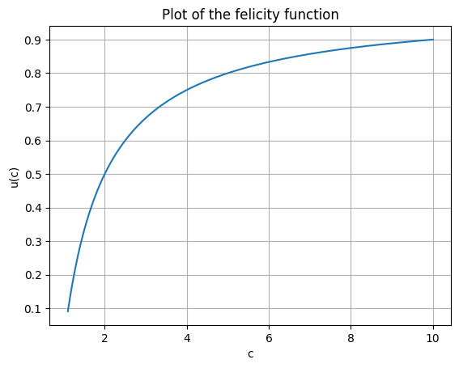

```python
# graphing the felicity function

def ff(c):
    return 1 - c ** -1

# Generate a range of values for c
c_values = np.linspace(1.1, 10, 400)  # Avoid division by zero by starting from 1.1

# Calculate the corresponding values of f(c)
f_values = ff(c_values)

# Create the plot
plt.plot(c_values, f_values, label=r'$f(c) = 1 - c^{-1}$')
plt.xlabel('c')
plt.ylabel('u(c)')
plt.title('Plot of the felicity function')
plt.grid(True)
plt.show()
```

This felicity function exhibits diminishing marginal returns to consumption

# Asset Price Equation as a Function of the State

we know the consumer's utility is defined by $u(c_0 -qz) + \beta[\pi_1 u(c_1(s_1) + r_1 z) + \pi_2u(c_1(s_2) + r_2z)]$

where q = price, z = quantity purchased. We maximize with respect to z

$\implies 0 = -qu'(c_0-qz) + \beta[\pi_1 u'(c_1(s_1) + r_1 z)r_1 + \pi_2u(c_1(s_2) + r_2 z)r_2]$

Because the optimal price will leave us indifferent to buying a unit of the good, we set z = 0, to find

$q = \frac{\beta}{u'(c_0)}[\pi_1 u'(c_1(s_1))r_1 + \pi_2u'(c_1(s_2))r_2]$

The probabilities $\pi_1$ and $\pi_2$ will vary based on the current state, and are given to us in the markov matrix

$$ \implies q(s_i) = \begin{cases} \frac{\beta}{u'(c(s_1))}[(0.8) u'(c(s_1))r_1 + (0.2)u(c(s_2))r_2], & \text{if } i = 1 \\ \frac{\beta}{u'(c(s_2))}[(0.1) u'(c(s_1))r_1 + (0.9)u(c(s_2))r_2], & \text{if } i = 2 \end{cases} $$

# Asset Price for Each state

If we plug in the parameter values given above, we find the following;

$q(s_1) = 0.97 (0.8 + 0.191) = 0.96$

# Long-Run Distribution of States

We can leverage the quant econ package to derive the stationary distribution for M. This is the distribution such that $[\pi_1, \pi_2]M = [\pi_1, \pi_2]$

```python
M = [
    [0.8, 0.2],
    [0.1, 0.9]
    ]

mc = qe.MarkovChain(M)
mc.stationary_distributions  # Show all stationary distributions
```

```
array([[0.33333333, 0.66666667]])
```

# Long Run Average Price of Stock

The long run average price of a stock will be determined by the stationary distribution. We simply take the expected value of the price;

$E[q(s_i)] = \pi_1 * q(s_1) + \pi_2 * q(s_2) = 0.33 * 0.96 + 0.66 * 1.05 = 1.01$

# Categorizing Time Series

```python
time_series = pd.read_excel(r"C:\Users\jonat\OneDrive\econometrics\dynamic_stochastic\data\time_series_midterm_2025.xlsx")
time_series.head()
```

|  | x1 | x2 | x3 | x4 |
| --- | --- | --- | --- | --- |
| 0 | 0.647689 | 0.677899 | 0.647689 | 0.647689 |
| 1 | 1.911643 | 1.819221 | 2.170718 | 2.105950 |
| 2 | 0.718526 | 0.656899 | 1.936565 | 1.661201 |
| 3 | -0.376514 | -0.046608 | 1.702428 | 1.260944 |
| 4 | 1.137746 | 1.415314 | 3.281641 | 2.714063 |

```python
# decompose into our four time series

ts1 = time_series["x1"]
ts2 = time_series["x2"]
ts3 = time_series["x3"]
ts4 = time_series["x4"]
```

# Plotting the Time Series

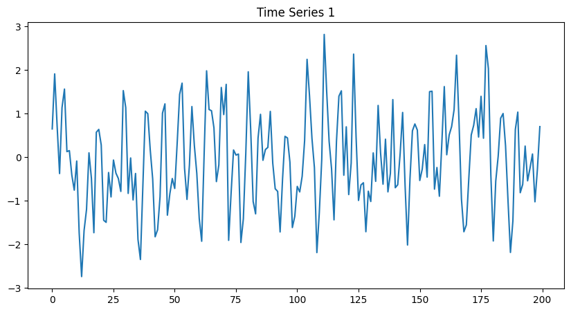

```python
ts1.plot(title="Time Series 1", figsize=(10,5))
plt.show()
```

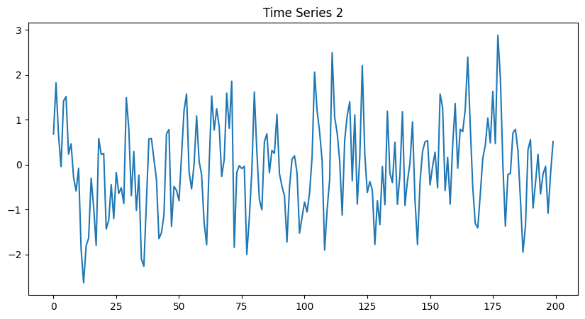

```python
ts2.plot(title="Time Series 2", figsize=(10,5))
plt.show()
```

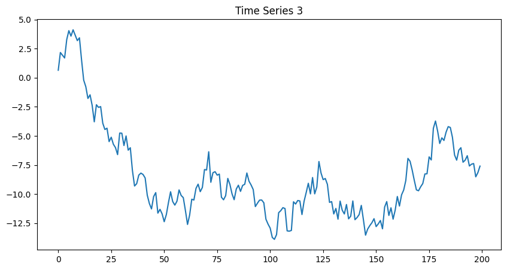

```python
ts3.plot(title="Time Series 3", figsize=(10,5))
plt.show()
```

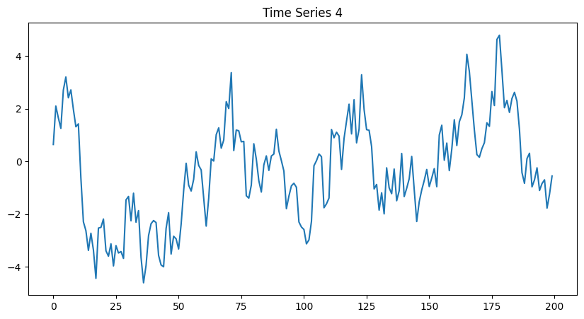

```python
ts4.plot(title="Time Series 4", figsize=(10,5))
plt.show()
```

# Plotting Autocorrelations

AR(1): Exhibits an exponentially decaying autocorrelation, with the decay rate directly determined by the parameter 𝜙

AR(2): The autocorrelation function can be a combination of exponentials or exhibit damped oscillations depending on whether the characteristic roots are real or complex.

MA(2): Has non-zero autocorrelations only for lags 1 and 2, and then zero for all higher lags.

Random Walk: The levels of a random walk are highly persistent (very high autocorrelation), but this is a feature of its non-stationarity; differenced, it becomes white noise.

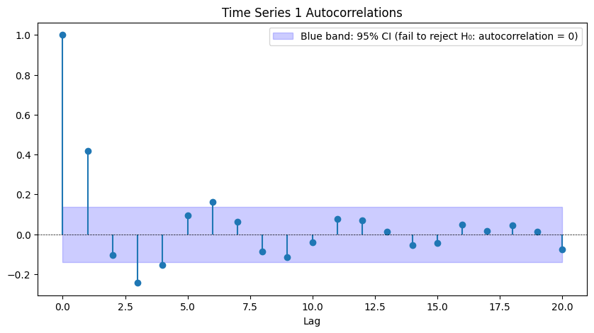

```python
# Compute ACF without confidence intervals from statsmodels
acf_values = acf(ts1, nlags=20)

# Create an array of lag values
lags = np.arange(len(acf_values))

# Compute the 95% confidence bound for white noise
N = len(ts1)
conf_bound = 1.96 / np.sqrt(N)

plt.figure(figsize=(10, 5))
plt.title("Time Series 1 Autocorrelations")
plt.xlabel("Lag")

# Plot the ACF using a stem plot
plt.stem(lags, acf_values, basefmt=" ")

# Add a blue band for the 95% confidence region around zero,
# indicating the region where we fail to reject H0: autocorrelation = 0.
plt.fill_between(lags, -conf_bound, conf_bound, color='blue', alpha=0.2,
                 label='Blue band: 95% CI (fail to reject H₀: autocorrelation = 0)')

# Draw a horizontal line at zero for reference
plt.axhline(0, color='black', linewidth=0.5, linestyle='--')

# Add legend
plt.legend()

plt.show()
```

This time series exhibits complex oscillatory behavior after the first two lags, meaning it is an AR2 process. I had trouble differentiating this from the MA2 process, but I made my decision based on the fact that there were statistically significant deviations from zero autocorrelation past lag two, a characteristic not present in MA2 processes.

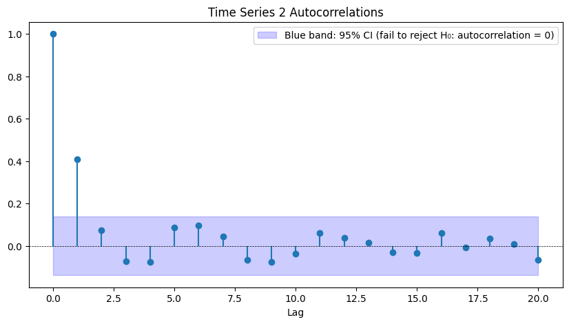

```python
# Compute ACF without confidence intervals from statsmodels
acf_values = acf(ts2, nlags=20)

# Create an array of lag values
lags = np.arange(len(acf_values))

# Compute the 95% confidence bound for white noise
N = len(ts2)
conf_bound = 1.96 / np.sqrt(N)

plt.figure(figsize=(10, 5))
plt.title("Time Series 2 Autocorrelations")
plt.xlabel("Lag")

# Plot the ACF using a stem plot
plt.stem(lags, acf_values, basefmt=" ")

# Add a blue band for the 95% confidence region around zero,
# indicating the region where we fail to reject H0: autocorrelation = 0.
plt.fill_between(lags, -conf_bound, conf_bound, color='blue', alpha=0.2,
                 label='Blue band: 95% CI (fail to reject H₀: autocorrelation = 0)')

# Draw a horizontal line at zero for reference
plt.axhline(0, color='black', linewidth=0.5, linestyle='--')

# Add legend
plt.legend()

plt.show()
```

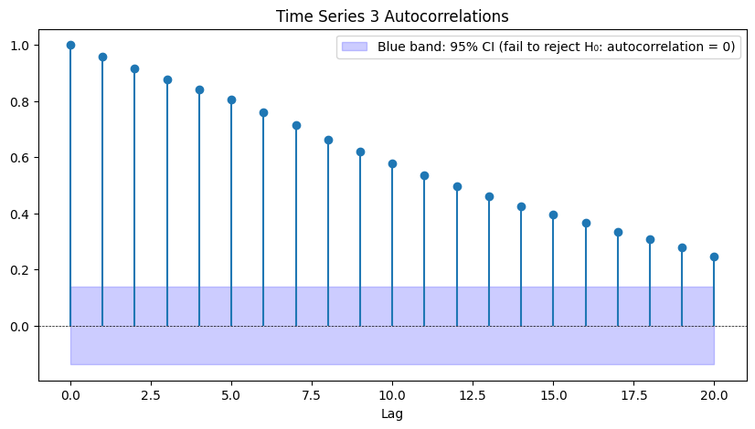

```python
# Compute ACF without confidence intervals from statsmodels
acf_values = acf(ts3, nlags=20)

# Create an array of lag values
lags = np.arange(len(acf_values))

# Compute the 95% confidence bound for white noise
N = len(ts3)
conf_bound = 1.96 / np.sqrt(N)

plt.figure(figsize=(10, 5))
plt.title("Time Series 3 Autocorrelations")
plt.xlabel("Lag")

# Plot the ACF using a stem plot
plt.stem(lags, acf_values, basefmt=" ")

# Add a blue band for the 95% confidence region around zero,
# indicating the region where we fail to reject H0: autocorrelation = 0.
plt.fill_between(lags, -conf_bound, conf_bound, color='blue', alpha=0.2,
                 label='Blue band: 95% CI (fail to reject H₀: autocorrelation = 0)')

# Draw a horizontal line at zero for reference
plt.axhline(0, color='black', linewidth=0.5, linestyle='--')

# Add legend
plt.legend()

plt.show()
```

Because this time series exhibits uniform, slow decay, we know that time series 3 is a random walk

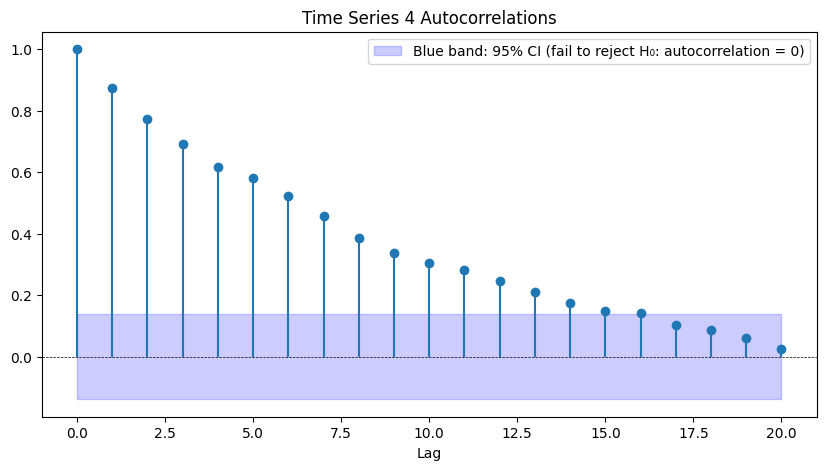

```python
# Compute ACF without confidence intervals from statsmodels
acf_values = acf(ts4, nlags=20)

# Create an array of lag values
lags = np.arange(len(acf_values))

# Compute the 95% confidence bound for white noise
N = len(ts4)
conf_bound = 1.96 / np.sqrt(N)

plt.figure(figsize=(10, 5))
plt.title("Time Series 4 Autocorrelations")
plt.xlabel("Lag")

# Plot the ACF using a stem plot
plt.stem(lags, acf_values, basefmt=" ")

# Add a blue band for the 95% confidence region around zero,
# indicating the region where we fail to reject H0: autocorrelation = 0.
plt.fill_between(lags, -conf_bound, conf_bound, color='blue', alpha=0.2,
                 label='Blue band: 95% CI (fail to reject H₀: autocorrelation = 0)')

# Draw a horizontal line at zero for reference
plt.axhline(0, color='black', linewidth=0.5, linestyle='--')

# Add legend
plt.legend()

plt.show()
```

Because this series exhibits exponential decay with no oscillation, we know time series 4 is an AR1 process

# Maximum Likelihood Estimation for Time Series Parameters

```python
def estimate_ar1_mle(series):
    """
    Estimate MLE parameters for an AR(1) process with no constant term.
    """
    series = np.asarray(series)
    X_t = series[1:]
    X_t1 = series[:-1]
    phi_hat = np.sum(X_t * X_t1) / np.sum(X_t1 ** 2)
    return phi_hat

def estimate_ar2_mle(series):
    """
    Estimate MLE parameters for an AR(2) process with no constant term.
    """
    series = np.asarray(series)
    X_t = series[2:]
    X_t1 = series[1:-1]
    X_t2 = series[:-2]
    X = np.column_stack((X_t1, X_t2))
    y = X_t
    phi1_hat, phi2_hat = np.linalg.lstsq(X, y, rcond=None)[0]
    return phi1_hat, phi2_hat

def estimate_ma2_mle(series):
    """
    Estimate MLE parameters for an MA(2) process with no constant term.
    """
    series = np.asarray(series)
    T = len(series)
    def neg_log_likelihood(params):
        theta1, theta2 = params
        residuals = np.zeros(T)
        for t in range(2, T):
            residuals[t] = series[t] - (theta1 * residuals[t-1] + theta2 * residuals[t-2])
        log_likelihood = -0.5 * np.sum(residuals ** 2)
        return -log_likelihood
    initial_guess = [0, 0]
    result = minimize(neg_log_likelihood, initial_guess, method='L-BFGS-B')
    theta1_hat, theta2_hat = result.x
    return theta1_hat, theta2_hat
```

```python
beta_1, beta_2 = estimate_ar2_mle(ts1)
print(f"mle estimate betas for time series 1 (AR2 process); beta 1; {beta_1}, beta 2: {beta_2}")
beta_1m, beta_2m = estimate_ma2_mle(ts2)
print(f"mle estimate betas for time series 2 (MA2 process); beta 1; {beta_1m}, beta 2: {beta_2m}")
print("Because time series 3 is a random walk we know it has a unit root, and beta = 1")
print(f"mle estimated beta for the time series 4 (AR1 process); {estimate_ar1_mle(ts4)}")
```

```
mle estimate betas for time series 1 (AR2 process); beta 1; 0.5590243495883175, beta 2: -0.3360482632555875
mle estimate betas for time series 2 (MA2 process); beta 1; 0.43991309942774715, beta 2: 0.1476234130849778
Because time series 3 is a random walk we know it has a unit root, and beta = 1
mle estimated beta for the time series 4 (AR1 process); 0.8801351633938483
```

# Autocorrelations for the unit root:

The autocorrelations for the unit root look like a straight line that slopes down because of the persistence of shocks. Because each shock in a random walk permanently affects the time series, the autocorrelations aren't going to rapidly decay as they did for the other processes. Instead, there will be gradual, linear decay